# Zagłębiając się w ggplot2

## Kilka technicznych komentarzy

W programie R wszystko jest obiektem, też wykres wykonany z użyciem ggplot2. Wykres, podobnie jak każdy obiekt, można modyfikować, zapisywać, odtwarzać, serializować.

```r
ob <- ggplot(genderAvgs, aes(x=math, y=read, shape=CNT, colour=ST04Q01)) +
          geom_point(size=3) +
            scale_shape_manual(values=LETTERS[1:10]) +
            coord_equal()

summary(ob)
```

```
## data: CNT, ST04Q01, math, read, total [20x5]
## mapping:  x = math, y = read, shape = CNT, colour = ST04Q01
## scales:   shape
## faceting: facet_null()
## -----------------------------------
## geom_point: na.rm = FALSE, size = 3
## stat_identity:
## position_identity: (width = NULL, height = NULL)
```

```r
print(ob)
```

```r
plot(ob)
```

```r
save(ob, file="samplePlot.rda")
```

Wykresy można nanosić na wspólną przestrzeń, dzięki czemu można wykonać ,,tablicę rozdzielczą’’.

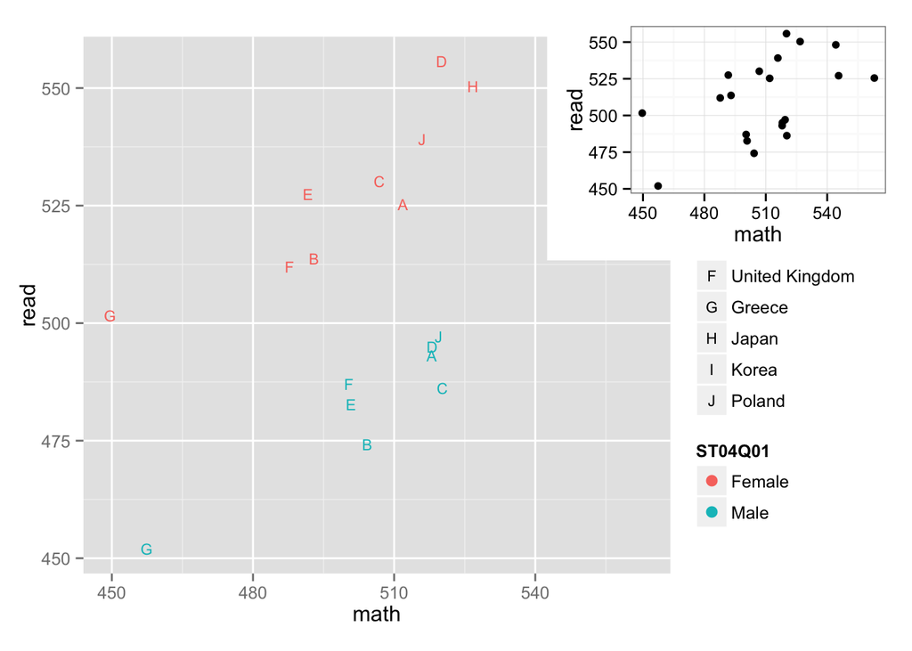

```r
library(gridExtra)
grid.newpage()
print(ob, vp=viewport(x=0.5, y = 0.5,
                          width=1, height=1))
print(ggplot(genderAvgs, aes(x=math, y=read)) + geom_point() + theme_bw(),
      vp=viewport(x=0.8, y = 0.8,
                          width=0.4, height=0.4))
```

## Motywy graficzne

Do tego miejsca, to szare tło mogło się już części z Państwa znudzić (warto zauważyć, że ma ono pewne zalety).

Bez obawy. Tło, jak i cały motyw można zmienić jedną instrukcją.

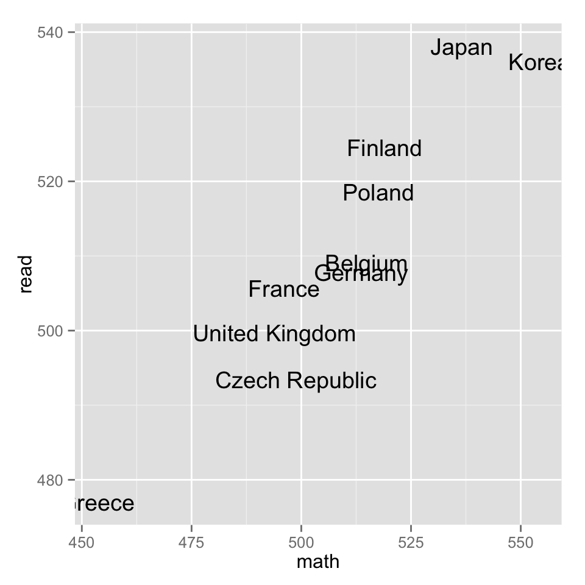

```r
avgs <- pisa %>%
          group_by(CNT) %>%
          summarise(math = weighted.mean(PV1MATH, W_FSTUWT, na.rm = TRUE),
                    read = weighted.mean(PV1READ, W_FSTUWT, na.rm = TRUE),
                    total = sum(W_FSTUWT))


ggplot(avgs, aes(x=math, y=read, label=CNT)) +
  geom_text()
```

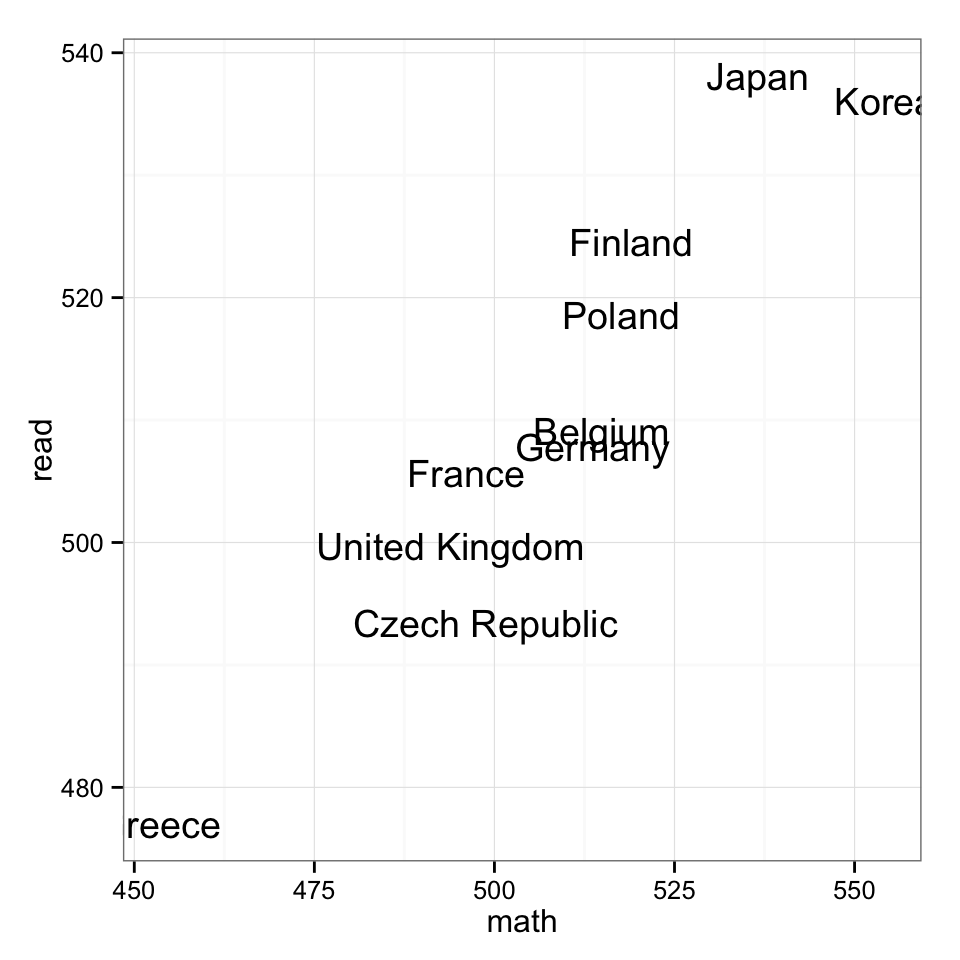

```r
ggplot(avgs, aes(x=math, y=read, label=CNT)) +
  geom_text() +
  theme_bw()
```

Dwa możliwe tła to nie jest zbyt wielki wybór. Ale można tworzyć własne motywy graficzne (tak dotyczące kolorystyki jak i wielkości elementów wykresu)

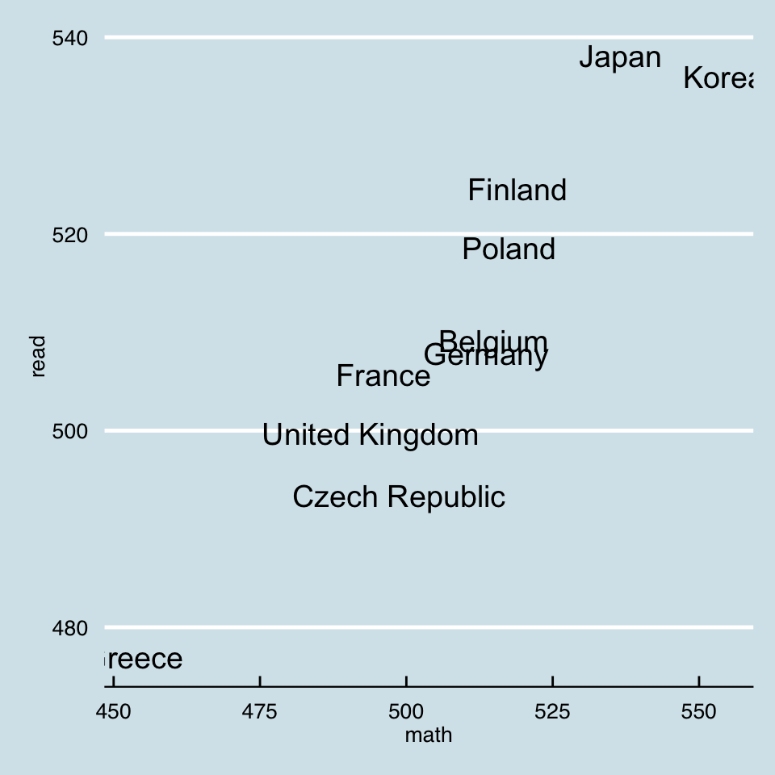

```r
library(ggthemes)
# na bazie magazynu The Economist
ggplot(avgs, aes(x=math, y=read, label=CNT)) +
  geom_text() +
  theme_economist()
```

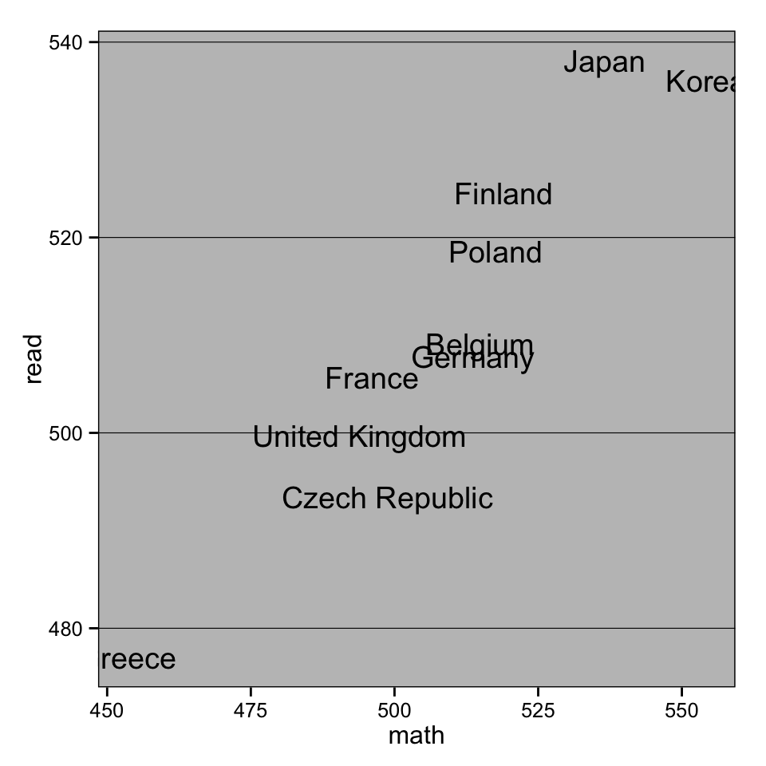

```r
# odtwarzanie wykresów w Excel
ggplot(avgs, aes(x=math, y=read, label=CNT)) +
  geom_text() +
  theme_excel()
```

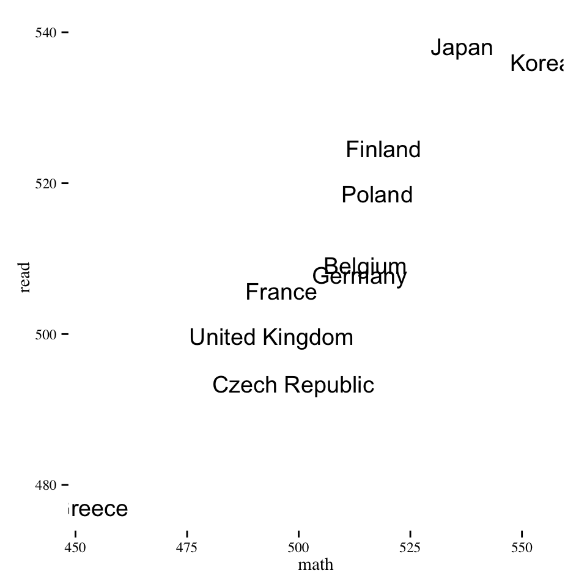

```r
# motyw 'minimal ink' bazujacy na książce Tufte: The Visual Display of Quantitative Information.
ggplot(avgs, aes(x=math, y=read, label=CNT)) +
  geom_text() +
  theme_tufte()
```

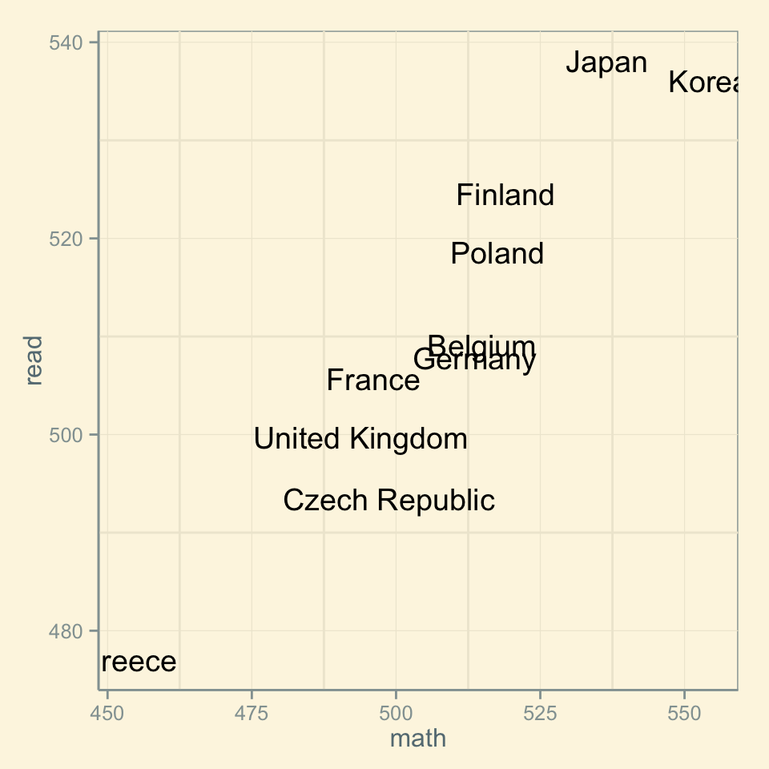

```r
# jasny motyw
ggplot(avgs, aes(x=math, y=read, label=CNT)) +
  geom_text() +
  theme_solarized()
```

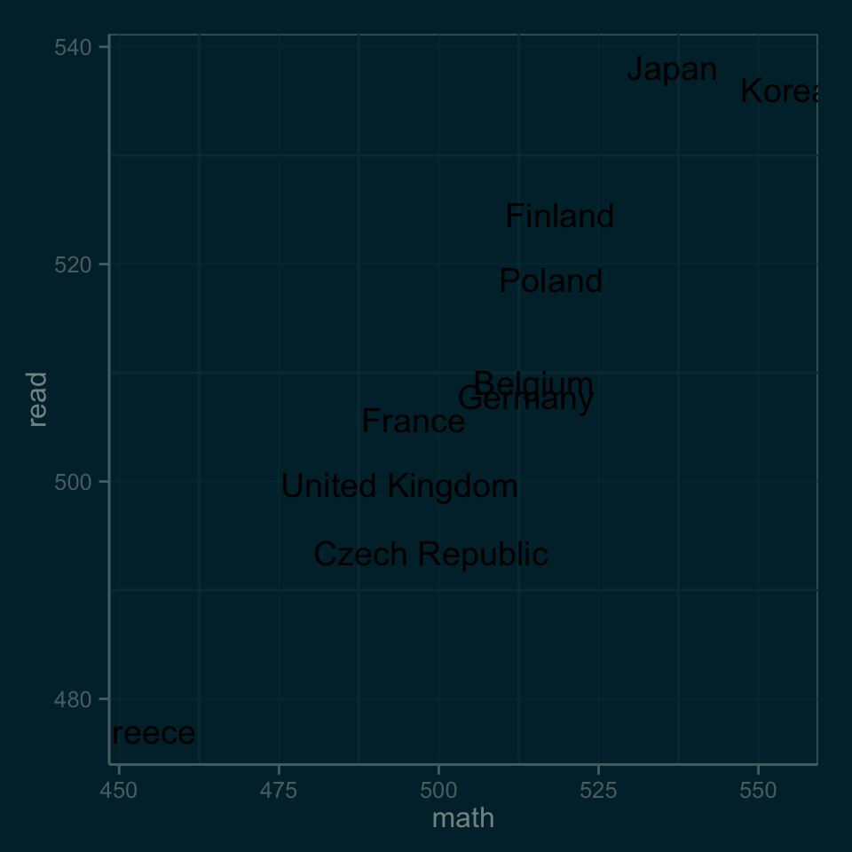

```r
# ciemny motyw
ggplot(avgs, aes(x=math, y=read, label=CNT)) +
  geom_text() +
  theme_solarized(light = FALSE)
```